# Activity 1.1: Getting Started with the Linux/Unix Command Line

Laura M. Carroll

3/26/2019

# 1 Introduction

**Goal:** Assess the quality of Illumina paired-end reads associated with a bacterial pathogen, before and after trimming

**Input:** Raw Illumina paired-end reads in gzipped fastq format (*.fastq.gz)

**Output:** Trimmed Illumina paired-end reads in gzipped fastq format (*.fastq.gz)

**Programs Used:**

- [FastQC](https://www.bioinformatics.babraham.ac.uk/projects/fastqc/): quality control for high throughput sequence data
- [Trimmomatic](http://www.usadellab.org/cms/?page=trimmomatic): adapter and low-quality sequence removal for Illumina reads

## 1.1 Learning Outcomes

- Access a remote workstation from the terminal
- Navigate in a Linux/Unix environment from the command line
- Learn and practice using commands to accomplish simple tasks
- Run software from the command line
- Copy files to/from a remote workstation
- Assess the quality of Illumina sequencing reads using FastQC
- Remove Illumina adapter sequences and low-quality bases using Trimmomatic

## 1.2 Background

### 1.2.1 Some terminal-ology

- **computer hardware**: physical elements of a computer
- **computer software**: instructions which tell computer hardware how to perform a task
- **application software**: a division of computer software; software which uses the computer system to perform functions beyond the basic operation of the computer itself
- **system software**: a division of computer software; software used to manage computer hardware behavior and provide a platform for other software to run

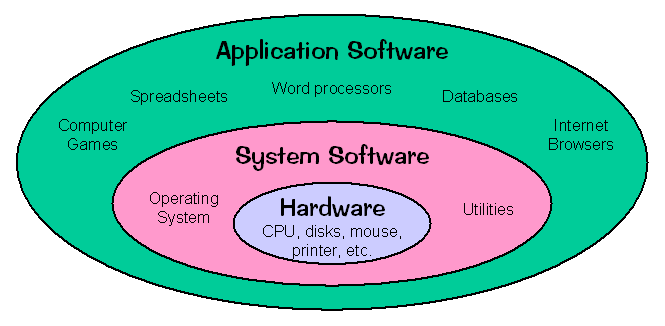

Figure 1: Differences between hardware, system software, and application software (Neeraj Mishra)

- **operating system (OS)**: a division of system software; system software that manages computer hardware and software resources and provides common services for computer programs. Examples include Microsoft Windows and macOS.
- **kernel**: component of an operating system; software at the core of a computer’s operating system which is used to mediate access to the computer’s resources
- **central processing unit (CPU)**: electronic circuitry within a computer which is responsible for running or executing programs; CPUs carry out the instructions of a computer program by performing the basic arithmetic, logic, controlling, and input/output (I/O) operations specified by the instructions
- **CPU core**: the processing unit of a CPU
- **thread**: thread of execution; an ordered sequence of instructions that tells the computer what to do

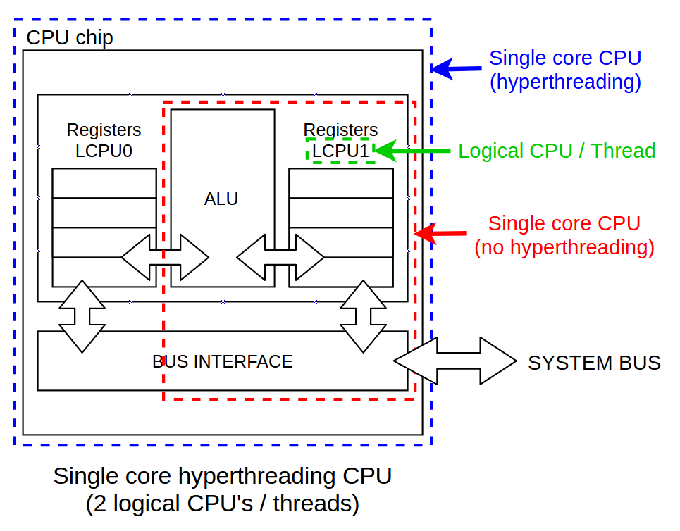

Figure 2: Components of a CPU (Daniel López Azaña)

- **random-access memory (RAM)**: a form of computer data storage which stores data and machine code that are currently being used
- **Unix shell**: also known as a shell; a command-line interpreter that provides a command line user interface for Unix-like operating systems
- **terminal emulator**: also known as a terminal; a text-based interface for typing commands, allowing users to interact with a Unix shell
- **graphical user interface (GUI)**: a form of user interface that allows users to interact with electronic devices through graphical icons and visual indicators

[figure not shown]

Figure 3: the Galaxy GUI, which provides a GUI for many bioinformatics tools (Wikipedia)

- **command-line interface (CLI)**: a means of interacting with a computer program where the user (or client) issues commands to the program in the form of successive lines of text (command lines)

### 1.2.2 What are Linux/Unix?

**Unix** is a family of operating systems that descend from the original Unix, which was developed in 1969 by Ken Thompson, Dennis Ritchie, Douglas McIlroy, and Joe Ossanna at AT&T’s Bell Laboratories in the United States (Ritchie, 1984, *AT&T Bell Laboratories Technical Journal*). In 1984, Bell Labs began distributing Unix as a proprietary product which users were not allowed to modify. Unix operating systems with which you may already be familiar are Apple’s macOS and Darwin (a component of what is now known as Apple’s macOS).

In 1983, Richard Stallman began the [GNU Project](https://www.gnu.org/gnu/manifesto.en.html) with the goal of creating a completely free Unix-compatible software system (in Stallman’s own words: [“Once GNU is written, everyone will be able to obtain good system software free, just like air.”](https://www.gnu.org/gnu/manifesto.en.html#f2)). By 1990, nearly all of the major components of a GNU operating system were finished; however, one important piece was still missing: [the kernel](https://www.gnu.org/gnu/gnu-history.html), which is where Linus Torvalds comes in. In 1991, while attending the University of Helsinki, Torvalds created a kernel which would later be released as the Linux kernel in 1992. By combining Linux with the GNU system, [a fully functioning operating system was born](https://www.gnu.org/gnu/gnu-history.html). **GNU/Linux**, or **Linux**, refers to this family of free, open-source, Unix-like operating systems based on the Linux kernel. Popular Linux distributions include Ubuntu, Debian, and Red Hat.

[figure not shown]

Figure 4: Tux the penguin, the Linux mascot (Wikipedia)

For this workshop, we will be doing nearly all of our computing in a Linux environment because

1. It’s free!
2. Bioinformaticians have and continue to rely heavily on Linux; a significant proportion of the software, tools, and piplines for analyzing next-generation sequencing (NGS) data are written specifically for Linux/Unix systems and can only be run from the Linux/Unix command line
3. An increasing number of web tools and desktop applications with graphical user interfaces (GUIs) are available for analyzing bacterial NGS data. However, even if you never, ever use Linux again, you will have a better understanding of what is going on “under-the-hood” for many of these applications

### 1.2.3 What is Bash?

**Bash** (Bourne-Again shell) refers to a Unix shell (a command-line interpreter that provides a command line user interface for Unix-like operating systems) and command language. It was written by Brian Fox for the GNU Project, with a beta version released in 1989. Since then, it has become the most popular Linux shell, as it is the default interactive shell for users on most Linux and macOS operating systems (which is why we will be using it for this workshop!). Bash allows users to type commands in a specific language, which the computer then executes.

### 1.2.4 The Linux File System

Before we start, it’s important to understand the structure of the Linux file system so we can navigate it from the command line.

If you’re a Windows user, you may be familiar with a file system that looks something like this:

[figure not shown]

Figure 5: Windows GUI (TechRepublic)

Mac users might understand their file systems as something that looks like this:

[figure not shown]

Figure 6: Mac GUI (O’Reilly)

The Linux file system isn’t so different; some popular Linux distributions, such as Ubuntu, might even have a very nice GUI, like the one below:

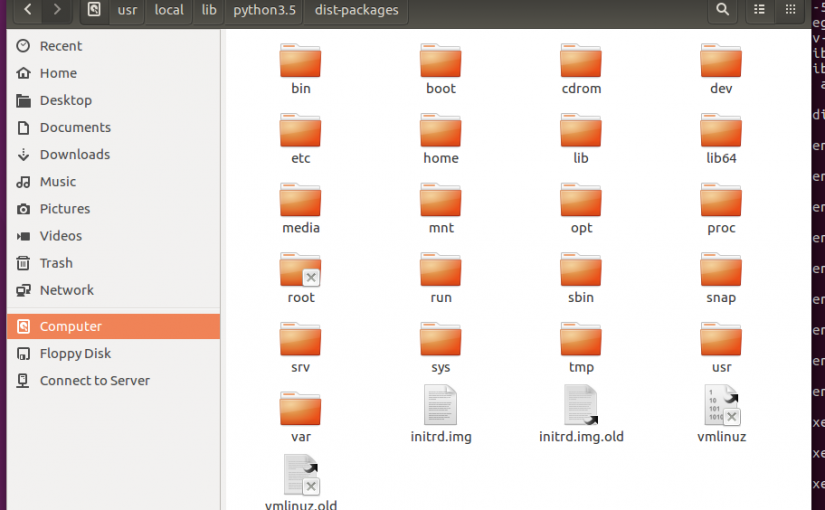

Figure 7: Ubuntu GUI (Me, IT and Tech)

However, when working from the command line, our view won’t be so pretty. But even without a GUI, we can imagine the underlying structure of the Linux file system as something resembling an upside-down tree, like the image below:

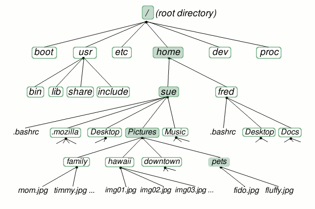

Figure 8: The Linux File System (LinuxPlanet)

**Files**, such as text files, image files, fastq files, fasta files, etc. are inside of directories. **Directories** are just another name for what one might call a “folder” in the Windows or Mac worlds. In the tree above (Figure 8; courtesty of [LinuxPlanet](http://www.linuxplanet.com/linuxplanet/tutorials/6666/1)), directories have green boxes around them, while files don’t.

If you look at the top of the tree (Figure 8), you’ll see a directory called the **root directory**, denoted by a forward slash (**/**). You can think of the root directory as the trunk of a tree from which all branches (**paths**) start.

One important thing to note before we begin is the difference between **absolute paths** and **relative paths**, which can be a frustrating concept for Linux command-line beginners. Paths are used to specify a particular file or directory; the **full path**, or **absolute path** to a file or directory starts from the root, /, and follows the branches of the files system, with each directory separated by a slash (/), until the file or directory of interest is reached. For example, in the tree above (Figure 8), if our file of interest is `fluffy.jpg`, the absolute path to `fluffy.jpg` is `/home/sue/Pictures/pets/fluffy.jpg` (just follow the shaded green boxes!). A relative path, on the other hand, specifies the path to a directory or file relative to another; usually, this is the directory you are currently in, also known as the **working directory**. So, for example, in the picture above (Figure 8), if we are currently inside the `home` directory, the relative path to `fluffy.jpg` is `sue/Pictures/pets/fluffy.jpg` (see how we didn’t start with a forward slash? That’s because we didn’t start at the root directory). If we move to the `Pictures` directory, our relative path to `fluffy.jpg` is `pets/fluffy.jpg`. Finally, if we move to the `pets` directory, the relative path to `fluffy.jpg` is just `fluffy.jpg`! However, the absolute path to `fluffy.jpg` remains `/home/sue/Pictures/pets/fluffy.jpg`.

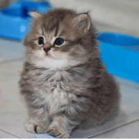

Figure 9: Actual image of fluffy.jpg? (tommy.thecat.2015)

Also, note that paths, file names, and directories are **case-sensitive**. For example, in the image above, if you search for `fluffy.jpg` at the following path `/home/sue/pictures/pets/fluffy.jpg`, Bash will throw an error saying that your file doesn’t exist. Why? Because the actual path is `/home/sue/Pictures/pets/fluffy.jpg`, where the `Pictures` directory has a capital “P”. If you don’t type the path correctly, Bash will look for a directory named `pictures` within `/home/sue/`, which doesn’t exist.

Finally, note that you should **try to avoid naming files and directories with special chacters**, particularly whitespace, slashes, asterisks, and other special characters. You’ll notice that bioinformaticians love underscores and dashes, so consider using those instead of hitting the space key when you’re naming a file or directory!

# 2 Activity 1.1

## 2.1 Access the remote workstation

First, we need to connect to a remote computer with a Linux operating system. This process is different for Windows and macOS users, so follow the instructions for your operating system.

### 2.1.1 Windows Users

Windows users will need to download an SSH client (a software program which uses the secure shell protocol to connect to a remote computer or server). The steps below will explain how to download and use PuTTY, which is one such SSH client (but if you already have a favorite SSH client for Windows, feel free to skip this step and use that!)

1. [Download PuTTY for Windows](https://www.ssh.com/ssh/putty/download#sec-Download-PuTTY-installation-package-for-Windows)
2. [Follow the instructions](https://www.ssh.com/ssh/putty/windows/install) for installing PuTTY on Windows
3. Double-click the PuTTY icon to run it (or find PuTTY from the Windows Start menu in the bottom left corner of the screen, and click to run it).
4. In the box labeled “Host Name (or IP address)”, enter the computer’s IP address (lfs-rdl-fsc-869.landfood.ubc.ca) and click “Open”
5. Type in your password (don’t be alarmed when you don’t see any characters when you are typing…that is supposed to happen!) and hit “Enter”

Congrats! You’re in!

### 2.1.2 macOS Users

Mac users will use the native SSH client (a software program which uses the secure shell protocol to connect to a remote computer or server).

1. Open your terminal by holding the `Command` and `Space` keys, typing “Terminal” into the Spotlight Search bar, and pressing `Enter`
2. Type the following command into your terminal, replacing `myUsername` with your own user name, and press `Enter`:

   ```
   ssh myUsername@lfs-rdl-fsc-869.landfood.ubc.ca
   ```

3. When prompted, type your password (don’t be alarmed when you don’t see any characters when you are typing…that is supposed to happen!), and press `Enter`

Congrats! You’re in!

## 2.2 Navigating in a Linux Environment

Now that we’re connected to our Linux workstation, let’s learn some simple commands which will help us navigate the Linux directory structure.

1. Let’s get the path to our **working directory**, i.e., figure out which directory (folder) we are currently in; to do this, we will use the `pwd` command (**p**rint **w**orking **d**irectory). To run `pwd`, type the following command below, and press `Enter`:

```
pwd
```

You should see the following text displayed, where myUsername is replaced with your own user name: /home/myUsername

We are currently in our home directory!

2. Now, just for fun, let’s familiarize ourself with some simple commands which we can use to tell us information about our computer. Type each of the following commands (each outlined by a box) into your terminal, and press `Enter` after each to see what happens.

`hostname` prints the system host name:

```
hostname
```

`whoami` prints who you are logged in as (your user name):

```
whoami
```

`date` prints the current date and time:

```
date
```

`cal` will show this month’s calendar:

```
cal
```

3. Now let’s see how much free and used memory we have, using the `free` command:

```
free
```

That’s a lot of numbers!

What happens when we add the `-h` option after `free`?

```
free -h
```

It makes the output much easier to read!

Luckily, we don’t need to memorize which options are available for which commands. To see this information (and much, much more), we can look at the manual for a particular command using the `man` command. Let’s take a look at the manual for the command `free`:

```
man free
```

Take a quick scroll through the manual for the `free` command using your up and down arrow keys. According to the manual, adding the `-h` option makes the output human-readable, as `-h` is the short form of the `--human` option.

Another useful option for `free` is `--help`.

Once you’ve gotten an idea of what a manual for a command looks like, you can exit by pressing `q`.

What do you think will happen when we run the following command?

```
free --human
```

Hopefully, you’ll see that the output of this command is identical to that produced using the `free -h` command we ran above.

Additionally, according to the manual for `free`, we can print a simple help message for `free` by including the `--help` option. Let’s see what happens when we try that:

```
free --help
```

Whenver we need to look up what a command does, how to run it, and what options are available to use with it, we can look at the manual using the `man` command or the `--help` option…even `man` has its own manual!

```
man man
```

To exit, press `q`.

4. Now that we have an idea of how to run some simple commands and, more importantly, where we can go for help (often `man` or `--help`), let’s try to navigate within the Linux environment.

We’ll start by taking a look at everything in our working directory (which, as we know when we used the command `pwd` to print our working directory, is our home directory).

We’ll do this using the `ls` command, which lists the contents of a directory. When we don’t supply a path to `ls`, it will list the contents of our working directory (i.e., the directory we are currently in: our home directory!):

```
ls
```

5. Just for fun, let’s create a new directory within our home directory named `hello`. We can do this by using the `mkdir` command (**m**a**k**e **dir**ectory), and supplying a path and name for our new directory, which in our case here will just be `hello`:

```
mkdir hello
```

6. Now, let’s move to our new directory, `hello`. We can **c**hange **d**irectories by using the `cd` command and supplying the path to the directory into which we want to move (in our case, we want to move to the `hello` directory that we just created within our working directory):

```
cd hello
```

7. How do we know if we changed directories? Use `pwd` to print our working directory!

```
pwd
```

We should see that we’re no longer in our home directory; now we’re in `hello`!

8. Now that we’re in our new directory, `hello`, let’s practice copying a file into our new directory using the `cp` command.

To use `cp`, we need to supply the path to the source file, which we want to copy, as well as the path to the destination directory (where we want to copy the file to).

Let’s copy a text file named `hello.txt` to our current working directory (the `hello` directory which we are now in).

For this workshop, all of our files are stored in a directory named `/home/labinstructor/wgs_workshop/`.

Let’s take a look at what is inside our `wgs_workshop` directory. To do so, we can use `ls` and supply the full path to the `wgs_workshop` directory:

```
ls /home/labinstructor/wgs_workshop
```

We should see several directories inside of `wgs_workshop`, each named after the activity.

The file we want for this activity, `hello.txt`, is located in the `activity1_1` directory within the `wgs_workshop` directory. Let’s double check this by using `ls` command to list the contents of `activity1_1`:

```
ls /home/labinstructor/wgs_workshop/activity1_1
```

We should see `hello.txt` listed!

Let’s copy `hello.txt` to our current directory, `hello`. To do this, we use `cp`, the path to `hello.txt` (`/home/labinstructor/wgs_workshop/activity1_1/hello.txt`), and the path to our directory, `hello` (`/home/myUsername/hello`, where myUsername is your own username):

```
cp /home/labinstructor/wgs_workshop/activity1_1/hello.txt /home/myUsername/hello
```

If we type `ls` (to list the contents of our current directory), we can see that `hello.txt` is now in our current directory!

```
ls
```

If we type `ls` and supply the path to the `activity1_1` directory (to list the contents of the `activity1_1` directory), we will see that `hello.txt` still exists in that directory:

```
ls /home/labinstructor/wgs_workshop/activity1_1
```

We just made a copy of the original file and stored it in our `hello` directory.

9. In addition to copying files, we can also move them using the `mv` command. To practice this, let’s create a new directory within `hello` called `ubc`. We do this using `mkdir` and supplying the path and name of our new directory. Because we are already in `hello`, we can just supply the relative path (i.e., the new name) of our new directory (i.e., `ubc`):

```
mkdir ubc
```

Let’s move `hello.txt` to our new directory, `ubc`, by typing `mv`, the path to `hello.txt`, and the path to `ubc`:

```
mv hello.txt ubc
```

If we type `ls`, we’ll see that our working directory, `hello`, now only contains `ubc`:

```
ls
```

And if we type `ls` and supply the path to `ubc`, we’ll see that `hello.txt` is now in `ubc`:

```
ls ubc
```

10. `mv` can also be used to rename files and directories. Let’s move `hello.txt` out of `ubc` and back into our `hello` directory. Additionally, let’s rename `hello.txt` to `goodbye.txt`.

```
mv ubc/hello.txt /home/myUsername/hello/goodbye.txt
```

If we type `ls` to list the contents of our working directory, we see that we now have a file named `goodbye.txt` in our current directory:

```
ls
```

If we type `ls` and supply the path to `ubc` (to list the contents of `ubc`), we will see that `ubc` is now empty:

```
ls ubc
```

11. Let’s delete `goodbye.txt` because we don’t need it anymore. To do this, we use the `rm` command and supply the path to the file that we want to delete:

```
rm goodbye.txt
```

If we type `ls` to list the contents of our current directory, we see that `goodbye.txt` has been deleted:

```
ls
```

**Importantly, be extra cautious when deleting files** with `rm`! Once they are gone, they are gone forever.

12. Now we know some simple commands for copying, moving, renaming, and deleting files, as well as for creating and changing directories. To set up for our first analysis, let’s rename our `hello` directory to something more meaningful, like `activity1`.

If we type `pwd` to print our working directory, we should see that we are still inside of the `hello` directory that we created:

```
pwd
```

To rename `hello` to `activity1` , we first need to move up a level, out of our `hello` directory using the `cd` command. There are a couple of ways we can do this.

The first way, we supply the full path to our home directory, which is the directory one level up from `hello`: `cd /home/myUsername`

However, this is super annoying to type! Another way we can move up a single level is to use `..` as our path, which is a shortcut that refers to the directory one level up from the working directory (in this case, our home directory): `cd ..`

A third way uses another shortcut; the tilde symbol, `~`, is a shortcut to your home directory. Try typing the following to move to your home directory:

```
cd ~
```

If we type `pwd`, we will see that we are back in our home directory:

```
pwd
```

And if we type `ls` to list the contents of our current directory, we will see `hello` listed as a directory within our current directory (our home directory):

```
ls
```

Now, let’s rename `hello` to `activity1` using `mv`, the path to `hello`, and the path to and desired new name of our directory (`activity1`):

```
mv hello activity1
```

If we type `ls` to list the contents of our current directory, we will see that `hello` is now `activity1`:

```
ls
```

If we type `ls` and supply the path to `activity1`, we will see that `activity1` is empty, except for the `ubc` directory we created:

```
ls activity1
```

13. Let’s get rid of the empty `ubc` directory within our `activity1` directory because we don’t need it anymore. To do this, we can use the `rm` command with the `-d` option (which allows us to delete empty directories), supplying the path to our empty `ubc` directory:

```
rm -d activity1/ubc
```

Is the path we supplied to our empty `ubc` directory a relative path, or is it an absolute path? (Hint: the answer is in section 1.2.4 above!)

If we type `ls` and supply the path to `activity1`, we’ll see that `activity1` is now empty:

```
ls activity1
```

## 2.3 Assessing the quality of raw Illumina reads with FastQC

1. Now that we’re getting the hang of the command line, let’s analyze some genomic data! Let’s first move into our `activity1` directory:

```
cd activity1
```

If we type `pwd`, we will see that we are now inside of `activity1`:

```
pwd
```

If we type `ls`, we will see that our current directory (`activity1`) is empty:

```
ls
```

2. In the workshop directory, there are raw reads associated with a bacterial isolate. All we know is that the isolate was sequenced using an Illumina platform using paired-end reads with a Nextera library preparation, and that it came from a *Salmonella enterica* isolate.

If we type `ls` to see what’s in the `/home/labinstructor/wgs_workshop/activity1_1` directory, we’ll see that there are two files ending in .fastq.gz. These are the raw Illumina reads associated with our mystery isolate, Mystery Salmonella A: `mystery_salmonella_A_1.fastq.gz` contains the forward reads, while `mystery_salmonella_A_2.fastq.gz` contains the reverse reads. Both of these files are in fastq format (`.fastq`), compressed using gzip (`.gz`; a common method for compressing genomic data).

Let’s copy the forward reads into our current directory (`/home/myUsername/activity1`) using the cp command:

```
cp /home/labinstructor/wgs_workshop/activity1_1/mystery_salmonella_A_1.fastq.gz ~/activity1/
```

Remember `~`? It’s a shortcut for our home directory! (`/home/myUsername`)

If we type `ls`, we should see our forward reads in our current directory:

```
ls
```

Using the `~` in place of the path to our home directory shortens what we have to type; however, we can do even better! The `.` symbol stands for the path to our current directory, `/home/myUsername/activity1`. Let’s take advantage of this by copying the reverse reads to our current directory:

```
cp /home/labinstructor/wgs_workshop/activity1_1/mystery_salmonella_A_2.fastq.gz .
```

If we type `ls`, we’ll see that we now have forward and reverse reads in our current directory:

```
ls
```

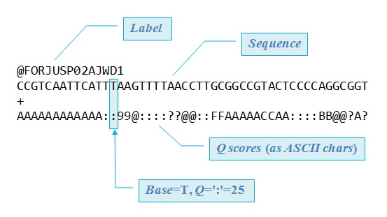

Figure 10: fastq format (USEARCH)

3. Now let’s run [FastQC](https://www.bioinformatics.babraham.ac.uk/projects/fastqc/), a popular program that is used to assess the quality of sequencing reads. It will provide us with a lot of interesting and valuable metrics which can help guide our downstream analyses (e.g., read length, number of reads, per-base quality, adapter content). Here, we will use FastQC to assess the quality of the raw reads of our mystery isolate.

The general format for running FastQC from the command line is as follows (note: don’t execute this command; it is just an example):

```
fastqc </path/to/first_reads.fastq.gz> </path/to/second_reads.fastq.gz> </path/to/third_reads.fastq.gz> </path/to/nth_reads.fastq.gz>
```

We will call the program (`perl /opt/FastQC/fastqc`), and we will supply the path to all of the reads we want to analyze, each separated by a space character.

Let’s try running FastQC with our forward and reverse reads. Because they are already in our current directory, we can just supply the names of the files:

```
perl /opt/FastQC/fastqc mystery_salmonella_A_1.fastq.gz mystery_salmonella_A_2.fastq.gz
```

Once FastQC is finished, we can type `ls` and see that we now have four additional files: a `.zip` and a `.html` file for our two `.fastq.gz` files with our forward and reverse Illumina raw reads:

```
ls
```

4. We are interested in looking at the html files, which contain FastQC’s quality assessment for our reads. Because we want to see all of the nice graphics in these html files, we’re going to need to copy them over to own computers. For this, we’ll use the secure copy protocol (SCP), which is a way to securely transfer computer files between a local host (our own computer) and a remote host (the computer on which we’ve been running our analyes).

**For Windows users:**

You can use a file transfer client such as [WinSCP](https://winscp.net/eng/index.php) or [FileZilla](https://filezilla-project.org/). If you haven’t already downloaded and installed one on your own computer, do so now. In both cases, to transfer files, you supply the IP address/name of the remote computer we’ve been working on, type in your password, and use the GUI to select which files you want to transfer. Here, you can select the two FastQC html files: `/home/myUsername/activity1/mystery_salmonella_A_1_fastqc.html` and `/home/myUsername/activity1/mystery_salmonella_A_2_fastqc.html`. Transfer them to the directory of your choice on your own computer.

**For macOS/Linux users:**

Mac users will use the `scp` command.

A. Open a new terminal by clicking “Shell” -> “New Window” -> “Basic” (or whatever terminal you’d like!)

B. Type the following command into your terminal, replacing `myUsername` with your own user name, and press `Enter`:

```
scp myUsername@lfs-rdl-fsc-869.landfood.ubc.ca:/home/myUsername/activity1/mystery_salmonella_A_1_fastqc.html .
```

C. When prompted, type your password (don’t be alarmed when you don’t see any characters when you are typing…that is supposed to happen!), and press `Enter`

This command copies the FastQC html file for your forward reads to your current directory (your home directory).

D. Now, for the reverse reads: type the following command into your terminal, replacing `myUsername` with your own user name, and press `Enter`:

```
scp myUsername@lfs-rdl-fsc-869.landfood.ubc.ca:/home/myUsername/activity1/mystery_salmonella_A_2_fastqc.html .
```

E. When prompted, type your password (don’t be alarmed when you don’t see any characters when you are typing…that is supposed to happen!), and press `Enter`

This command copies the FastQC html file for your reverse reads to your current directory (your home directory).

5. Open the FastQC html file for your forward and reverse reads (it should open in your browser); what sort of information can we gather about our sample?

## 2.4 Trimming raw Illumina reads with Trimmomatic

1. Now that we have a general idea of what the quality of our raw reads is like, let’s see if we can do better by cleaning up our raw reads. To that end, we’ll use [Trimmomatic](http://www.usadellab.org/cms/?page=trimmomatic) to trim our Illumina reads (i.e., remove Illumina adapter sequences and low-quality bases from our Illumina reads). Trimming can often improve read quality and, later, assembly. There are numerous trimming programs available (e.g., [AdapterRemoval v2](https://github.com/MikkelSchubert/adapterremoval), [Trim Galore/cutadapt](https://www.bioinformatics.babraham.ac.uk/projects/trim_galore/), and [bbduk](https://jgi.doe.gov/data-and-tools/bbtools/bb-tools-user-guide/bbduk-guide/), just to name a few), but here we will use Trimmomatic; it is a popular, fast, and relatively easy-to-use trimming program that, importantly, takes into account read pairing information for paired-end reads (most modern trimming software, including the Trimmomatic alternatives listed, should do this, but it’s always good to double-check beforehand if you try out something new).

Here, we will use Trimmomatic to:

A. Trim Illumina adapters left over from the Nextera library preparation

B. Use a sliding window approach to measure average quality within a 4-base window, trimming when the average per-base quality drops below a Phred quality score of 15

C. Remove trailing bases (i.e., bases at the end of a read) which drop below a Phred quality score of 3

D. Remove leading bases (i.e., bases at the start of a read) which drop below a Phred quality score of 3

E. Remove reads less than 36 bp in length (note that employing a minimum read length filter like we are doing here can be especially important for analyses which require counting of mapped reads, such as RNA-Seq)

Let’s get trimming! Back in your terminal, make sure you are in your `activity1` directory with the forward and reverse reads from our Mystery Salmonella A isolate (`mystery_salmonella_A_1.fastq.gz` and `mystery_salmonella_A_2.fastq.gz`):

```
pwd
```

should show that we are in our `activity1` directory

```
ls
```

should show `mystery_salmonella_A_1.fastq.gz` and `mystery_salmonella_A_2.fastq.gz`

(If not: `cd /home/myUsername/activity1`)

The command to run Trimmomatic for paired-end Illumina reads takes the following form (note: don’t execute this command; it is just an example):

[output not shown]

For this command, we are:

- Calling Trimmomatic (`java -jar trimmomatic-0.39.jar`)
- Telling Trimmomatic that we have paired-end (PE) reads (`PE`)
- Telling Trimmomatic that our Illumina reads have ASCII_BASE 33 quality scores and not the ASCII_BASE 64 quality scores used by very old Illumina platforms (`-phred33`)
- Telling Trimmomatic to create a log file named log.txt (`-trimlog log.txt`)
- Giving Trimmomatic the path to our forward reads in fastq.gz format (`input_forward.fq.gz`)
- Giving Trimmomatic the path to our reverse reads in fastq.gz format (`input_reverse.fq.gz`)
- Telling Trimmomatic what we want to name the trimmed forward read pairs that it outputs (`output_forward_paired.fq.gz`)
- Telling Trimmomatic what we want to name the trimmed forward unpaired reads that it outputs (`output_forward_unpaired.fq.gz`)
- Telling Trimmomatic what we want to name the trimmed reverse read pairs that it outputs (`output_reverse_paired.fq.gz`)
- Telling Trimmomatic what we want to name the trimmed reverse unpaired reads that it outputs (`output_reverse_unpaired.fq.gz`)
- Telling Trimmomatic to remove any Illumina adapters, with the adapter sequences provided in the adapters-PE.fa file (`ILLUMINACLIP:adapters-PE.fa:2:30:10`)
- Telling Trimmomatic to remove leading low quality or N bases below quality 3 (`LEADING:3`)
- Telling Trimmomatic to remove trailing low quality or N bases below quality 3 (`TRAILING:3`)
- Telling Trimmomatic to scan each read with a 4-base wide sliding window, cutting when the average quality per base drops below 15 (`SLIDINGWINDOW:4:15`)
- Telling Trimmomatic to drop reads less than 36 bases long (`MINLEN:36`)
2. Let’s run Trimmomatic by typing in the following (very long!) command as follows, and then pressing “Enter”:

[output not shown]

What are we doing when we run this?

- Calling Trimmomatic (`java -jar /opt/Trimmomatic-0.39/trimmomatic-0.39.jar`)
- Telling Trimmomatic that we have paired-end (PE) reads (`PE`)
- Telling Trimmomatic that our Illumina reads have ASCII_BASE 33 quality scores and not the ASCII_BASE 64 quality scores used by very old Illumina platforms (`-phred33`)
- Telling Trimmomatic to create a log file named log.txt (`-trimlog log.txt`)
- Giving Trimmomatic the path to our forward reads in fastq.gz format (`mystery_salmonella_A_1.fastq.gz`)
- Giving Trimmomatic the path to our reverse reads in fastq.gz format (`mystery_salmonella_A_2.fastq.gz`)
- Telling Trimmomatic what we want to name the trimmed forward read pairs that it outputs (we can technically name this file anything, but let’s call it `mystery_salmonella_A_trimmedP_1.fastq.gz`; the _1.fastq.gz suffix lets us know that the file contains forward reads, while trimmedP lets us know that these reads are trimmed read pairs)
- Telling Trimmomatic what we want to name the trimmed forward unpaired reads that it outputs (similar to before, we can name this anything, but let’s call it `mystery_salmonella_A_trimmedS_1.fastq.gz` because they are trimmed forward **S**INGLE [unpaired] reads)
- Telling Trimmomatic what we want to name the trimmed reverse read pairs that it outputs (to be consistent, `mystery_salmonella_A_trimmedP_2.fastq.gz`)
- Telling Trimmomatic what we want to name the trimmed reverse unpaired reads that it outputs (to be consistent, `mystery_salmonella_A_trimmedS_2.fastq.gz`)
- Telling Trimmomatic to remove Illumina Nextera paired-end adapters, with the adapter sequences provided in the NexteraPE-PE.fa file (`ILLUMINACLIP:/opt/Trimmomatic-0.39/adapters/NexteraPE-PE.fa:2:30:10`)
- Telling Trimmomatic to remove leading low quality or N bases below quality 3 (`LEADING:3`)
- Telling Trimmomatic to remove trailing low quality or N bases below quality 3 (`TRAILING:3`)
- Telling Trimmomatic to scan each read with a 4-base wide sliding window, cutting when the average quality per base drops below 15 (`SLIDINGWINDOW:4:15`)
- Telling Trimmomatic to drop reads less than 36 bases long (`MINLEN:36`)
3. Once Trimmomatic is finished, let’s take a look at the sizes of our fastq.gz files to get a rough idea of the effect trimming had on our genome. To do this, we can use `ls` with the `-l` and `-h` options to list our files and their respective sizes in human-readable format; we can additionally supply `*.fastq.gz` after the command, which allows us to only list files ending in .fastq.gz:

   ```
   ls -lh *.fastq.gz
   ```

## 2.5 Assessing the quality of trimmed Illumina reads with FastQC

1. Now let’s run FastQC on our trimmed paired reads (forward and reverse):

   ```
   perl /opt/FastQC/fastqc mystery_salmonella_A_trimmedP_1.fastq.gz mystery_salmonella_A_trimmedP_2.fastq.gz
   ```

2. Follow the instructions for copying the resulting html files to your local computer (See Section 2.3, Step #4, but replace the filenames for the forward and reverse reads with `mystery_salmonella_A_trimmedP_1_fastqc.html` and `mystery_salmonella_A_trimmedP_2_fastqc.html`, respectively), and open them. Has the quality of your reads improved?

# 3 Supplemental Activities

Have extra time? The following Supplemental Readings and Activities are designed to give you extra practice with some of the tools and/or topics covered in this Activity, as well as to introduce some new concepts for participants who want an extra challenge. Feel free to work on all of the activities/readings, or pick your favorite (or, feel free to work on your own projects, or just relax!).

## 3.1 Supplemental Readings

**Topic: using NGS to query food-associated microbes and communities**

Kovac, Jasna, Henk den Bakker, Laura M. Carroll, Martin Wiedmann. 2017. [Precision food safety: a systems approach to food safety facilitated by genomics tools.](https://www.sciencedirect.com/science/article/pii/S0165993617301176) *TrAC Trends in Analytical Chemistry* doi: 10.1016/j.trac.2017.06.001.

Taboada, Eduardo N., Morag R. Graham, João A. Carriço, Gary Van Domselaar. 2017. [Food Safety in the Age of Next Generation Sequencing, Bioinformatics, and Open Data Access.](https://www.frontiersin.org/articles/10.3389/fmicb.2017.00909/full). *Frontiers in Microbiology* 8: 909. DOI: 10.3389/fmicb.2017.00909.

Wiedmann, Martin and Laura M. Carroll. 2018. Next-generation sequencing. In *Reference Module in Food Science*. doi: 10.1016/B978-0-08-100596-5.21792-7. (Note: this is sadly not open access, but the reading should be provided to you in the e-mail with the lecture slides)

## 3.2 FastQC Redux

There are Illumina reads, named `FOO_BR_2016_cesNegative_SRR5877988_1.fastq.gz` and `FOO_BR_2016_cesNegative_SRR5877988_2.fastq.gz`, from an additional bacterial isolate (*Bacillus cereus* isolated from a Requeijao cheese in Brazil in 2016) in the following directory: `/home/labinstructor/wgs_workshop/supplemental_activity1_1`. Copy them to your `activity1` directory, and use FastQC to assess their quality. Can you think of a way to run the FastQC command with both forward and reverse reads as input, without typing the full file names of each? Do you notice any differences between this genome and our mystery *Salmonella* genome in terms of sequencing quality? Try trimming the forward and reverse reads for this *Bacillus cereus* genome; does this improve the quality? Why or why not?

## 3.3 Writing simple scripts in Bash

We used Trimmomatic to trim raw Illumina reads associated with a bacterial isolate; however, what if we had 10 isolates? 100? 1,000? Rather than typing in the command to run Trimmomatic on each set of paired-end reads, we can use Bash to write a simple script that loops through our read pairs, trimming each set:

[output not shown]

We’ll go through this line-by-line:

```
#!/bin/bash
```

This line is called a shebang; the part after `#!` tells the operating system to invoke the Bash shell to execute the commands in the script.

```
for f in *_1.fastq.gz
do
```

We’re telling the computer to loop through all files ending in _1.fastq.gz (i.e., each file containing forward reads), running the command(s) that follow. We will use the variable `f` to represent each _1.fastq.gz file (i.e., each file containing forward reads for each genome).

[output not shown]

This is the Trimmomatic command that we used before, but with a couple of key differences; for forward reads, we specify `$f`. This tells Bash to run the command with whichever forward read file is stored as the variable `f`. For our reverse reads, we specify `${f%_1.fastq.gz}_2.fastq.gz`. This tells the computer to take all of the text up to _1.fastq.gz for our current variable `f`, and append the suffix _2.fastq.gz; so basicaly, what we’re doing is specifying the reverse reads that match our forward reads, assuming they are identically named except for the _1.fastq.gz and _2.fastq.gz suffix. The same logic applies for the names of the output files, as well as the logfile. Bash runs this command for each set of reads, executing Trimmomatic on each.

```
done
```

We’re telling Bash that this is the end of our loop.

To run the script, we can save it as something, such as `trimmomatic.sh` (where `.sh` indicates that it is a shell script written in Bash), move it to the directory in which we have all of our paired-end reads, and enter the following command:

```
sh trimmomatic.sh
```

With this command, we tell the shell (`sh`, which in our case is Bash) to run the commands in our script.

FastQC conveniently lets us list all of the files we want to run in a single command; however, just for fun, a user could write a simple loop, similar to the Trimmomatic script shown above, to run the `fastqc` command on each file containing Illumina reads. Using what you know about FastQC and Bash, try writing a simple Bash script to accomplish this. Which is faster for paired-end reads from a single bacterial isolate…running FastQC with a single command (as done in the main activity), or running FastQC in your loop?

# 4 References

Babraham Bioinformatics. [FastQC: a quality control tool for high throughput sequence data.](https://www.bioinformatics.babraham.ac.uk/projects/fastqc/) Accessed April 14, 2019. URL: https://www.bioinformatics.babraham.ac.uk/projects/fastqc/

Bolger, A.M., M. Lohse, and B. Usadel. 2014. [Trimmomatic: a flexible trimmer for Illumina sequence data.](https://www.ncbi.nlm.nih.gov/pmc/articles/PMC4103590/) *Bioinformatics* 30(15): 2114-2120. DOI: 10.1093/bioinformatics/btu170.

JGI. [BBDuk: Decontamination Using Kmers.](https://jgi.doe.gov/data-and-tools/bbtools/bb-tools-user-guide/bbduk-guide/) Accessed April 15, 2019. URL: https://jgi.doe.gov/data-and-tools/bbtools/bb-tools-user-guide/bbduk-guide/

Krueger, F. and Babraham Bioinformatics. [Trim Galore: a wrapper tool around Cutadapt and FastQC to consistently apply quality and adapter trimming to FastQ files, with some extra functionality for MspI-digested RRBS-type (Reduced Representation Bisufite-Seq) libraries.](http://www.bioinformatics.babraham.ac.uk/projects/trim_galore/) Accessed April 15, 2019. URL: http://www.bioinformatics.babraham.ac.uk/projects/trim_galore/.

Martin, M. 2011. [Cutadapt removes adapter sequences from high-throughput sequencing reads.](https://journal.embnet.org/index.php/embnetjournal/article/view/200/479) *EMBnet.journal* 17(1): 10-12. DOI: https://doi.org/10.14806/ej.17.1.200.

Ritchie, D.M. 1984. [The UNIX system: The evolution of the UNIX time-sharing system.](https://onlinelibrary.wiley.com/doi/abs/10.1002/j.1538-7305.1984.tb00054.x) *AT&T Bell Laboratories Technical Journal* 63(8): 1577-1593. DOI: 10.1002/j.1538-7305.1984.tb00054.x.

Schubert, M., S. Lindgreen, and L. Orlando. 2016. [AdapterRemoval v2: rapid adapter trimming, identification, and read merging.](https://www.ncbi.nlm.nih.gov/pmc/articles/PMC4751634/) *BMC Research Notes* 9: 88. DOI: 10.1186/s13104-016-1900-2.

# 5 Linux Cheat Sheet

Print the contents of a file:

```
cat <path/filename>
```

Move to a different directory:

```
cd <path>
```

Move up one directory:

```
cd ..
```

Move to the root directory:

```
cd /
```

Move to your home directory:

```
cd ~
```

Copy the source file to the destination:

```
cp <source> <destination>
```

Copy the source directory to the destination:

```
cp -r <source> <destination>
```

Download a file from an online source (`curl`):

```
curl filename
```

Show disk usage:

```
df
```

Show directory space usage:

```
du
```

Find all instances of file in path with given name:

```
find <path> -name <pattern>
```

Show memory and swap usage in human-readable format:

```
free -h
```

Print all appearances of pattern in file:

```
grep <pattern> <path/filename>
```

Count all appearances of pattern in file:

```
grep -c <pattern> <path/filename>
```

Gzip file(s):

```
gzip path/filename
```

Decompress gzipped file(s):

```
gzip -d path/filename.gz
```

Print the first 10 lines of a file:

```
head <path/filename>
```

Print system hostname:

```
hostname
```

List the given path:

```
ls <path>
```

List the given path, showing permissions, size, and modification dates in human readable format:

```
ls -lh <path>
```

List the given path, showing permissions, size, and modification dates in human readable format, sorting by filesize from largest to smallest:

```
ls -lhS <path>
```

List the given path, showing permissions, size, and modification dates in human readable format, sorting by filesize from smallest to largest:

```
ls -lhSr <path>
```

View the manual for a command (press `q` to exit manual):

```
man <command>
```

Create a directory:

```
mkdir <path/directory_name>
```

Move the source file or directory to the destination:

```
mv <source> <destination>
```

Print working directory (where am I?):

```
pwd
```

Remove a file:

```
rm <path/filename>
```

Remove an empty directory:

```
rm -d <path/directory>
```

Remove a non-empty directory (use with caution!):

```
rm -r <path/directory>
```

Secure copy a file from remote server to the `dir` directory on your machine:

```
scp user@host:file dir
```

Secure copy a file from your machine to the `dir` directory on a remote server:

```
scp file user@host:dir
```

Secure copy the directory `foo` from remote server to the directory `bar` on your machine:

```
scp -r user@host:foo bar
```

Execute a shell script, script.sh:

```
sh script.sh
```

Connect to host as user:

```
ssh user@host
```

Print the last 10 lines of a file:

```
tail <path/filename>
```

Create a tar file, file.tar:

```
tar -cf file.tar path/directory
```

Extract a tar file, file.tar:

```
tar -xf file.tar
```

Create a gzipped tar file, file.tar.gz:

```
tar -czf file.tar.gz path/directory
```

Extract a gzipped tar file, file.tar.gz:

```
tar -xzf file.tar.gz
```

Download a file from an online source (`wget`):

```
wget filename
```

Print who you are logged in as:

```
whoami
```